# Polygenic risk scores predict hypertension

**Libraries**

```r
setwd("/home/ivm/red/ht_prs")

packrat::on()
library(tidyverse)
library(survival)   # survival analysis
library(data.table) # fread() function
library(gridExtra)  # plots to grid
library(survminer)  # ggbased visualization and extra diagnostics
library(survRM2)    # restricted mean survival times
library(visdat)     # visualization of tibble and na's
library(forestplot) # forestplot

source('/finngen/red/ht_prs/articles-functions.R')
```

# 1 Data

**Risk scores**

**Endpoints**

- I9_HYPTENS: Hypertension
- I9_CVD_HARD: Hard cardiovascular diseases
- I9_CHD: Major coronary heart disease event
- I9_STR: Ischaemic Stroke, excluding all haemorrhages.

**Copying and preprocessing data**

Endpoint and covariate files transfered and unzipped. Columns selected from endpoint file prior to import to r. There was not enough memory to upload full files to R.

```bash
#Endpoint file and covariate file copied and unzipped

cp /finngen/library-red/finngen_R5/phenotype_2.0/data/finngen_R5_V2_endpoint.gz /finngen/red/ht_prs/data/
cp /finngen/library-red/finngen_R5/phenotype_2.0/data/R5_cov_pheno_1.0.txt.gz /finngen/red/ht_prs/data/

gzip -d /finngen/red/ht_prs/data/finngen_R5_V2_endpoint.gz
gzip -d /finngen/red/ht_prs/data/R5_cov_pheno_1.0.txt.gz

#Self written perl-script to extract columns from phenotype file
perl select_columns.pl data/finngen_R5_V2_endpoint data/finngen_R5_V2_HTCVD FINNGENID I9_HYPTENS I9_HYPTENS_AGE I9_CVD_HARD I9_CVD_HARD_AGE I9_CHD I9_CHD_AGE I9_STR I9_STR_AGE FU_END_AGE

#This could be loaded directly to R, but now loading will be faster...
perl select_columns.pl data/R5_cov_pheno_1.0.txt data/R5_cov_pheno_selected FINNGENID batch BL_YEAR cohort SEX_IMPUTED PC1 PC2 PC3 PC4 PC5 PC6 PC7 PC8 PC9 PC10
```

**Loading data**

```r
endpoints <- fread("/finngen/red/ht_prs/data/finngen_R5_V2_HTCVD", sep = "\t")

sbp_prs <- fread("/finngen/red/test/ukb-sbp-both.profile") %>%
  select(IID, SCORE) %>%
  rename(SBP_SCORE=SCORE)

dbp_prs <- fread("/finngen/red/test/ukb-dbp-both.profile") %>%
  select(IID, SCORE) %>%
  rename(DBP_SCORE=SCORE)

covs <- fread("/finngen/red/ht_prs/data/R5_cov_pheno_selected")
```

**Combining data**

```r
df <- endpoints %>%
  left_join(sbp_prs, by = c("FINNGENID" = "IID")) %>%
  left_join(dbp_prs, by = c("FINNGENID" = "IID")) %>%
  left_join(covs, by = c("FINNGENID" = "FINNGENID"))

#Removing cases without genetic information and some other preprocessing
df <- df %>%
  filter(!is.na(batch)) %>%
  mutate_at(c("batch","cohort"),as.factor)

dim(df)
```

```
## [1] 218792     26
```

**Properties of variables**

```r
df_tmp <- df %>% select(I9_HYPTENS_AGE, I9_HYPTENS, SBP_SCORE, DBP_SCORE)
summary(df_tmp)
```

```
##  I9_HYPTENS_AGE     I9_HYPTENS       SBP_SCORE            DBP_SCORE
##  Min.   :  0.04   Min.   :0.0000   Min.   :-4.200e-07   Min.   :-4.451e-07
##  1st Qu.: 42.76   1st Qu.:0.0000   1st Qu.:-6.389e-08   1st Qu.:-6.407e-08
##  Median : 55.76   Median :0.0000   Median : 3.425e-10   Median : 1.319e-09
##  Mean   : 54.59   Mean   :0.2556   Mean   : 2.328e-10   Mean   : 2.073e-10
##  3rd Qu.: 66.89   3rd Qu.:1.0000   3rd Qu.: 6.471e-08   3rd Qu.: 6.520e-08
##  Max.   :118.92   Max.   :1.0000   Max.   : 3.908e-07   Max.   : 4.174e-07
##                   NA's   :38
```

```r
df_tmp2 <- df %>% select(I9_CVD_HARD, I9_CVD_HARD_AGE, I9_CHD, I9_CHD_AGE, I9_STR, I9_STR_AGE)
summary(df_tmp2)
```

```
##   I9_CVD_HARD     I9_CVD_HARD_AGE      I9_CHD          I9_CHD_AGE         I9_STR        I9_STR_AGE
##  Min.   :0.0000   Min.   :  0.00   Min.   :0.00000   Min.   :  0.26   Min.   :0.000   Min.   :  0.00
##  1st Qu.:0.0000   1st Qu.: 45.55   1st Qu.:0.00000   1st Qu.: 45.81   1st Qu.:0.000   1st Qu.: 45.95
##  Median :0.0000   Median : 59.59   Median :0.00000   Median : 59.98   Median :0.000   Median : 60.71
##  Mean   :0.1341   Mean   : 57.22   Mean   :0.09604   Mean   : 57.56   Mean   :0.055   Mean   : 58.06
##  3rd Qu.:0.0000   3rd Qu.: 70.04   3rd Qu.:0.00000   3rd Qu.: 70.51   3rd Qu.:0.000   3rd Qu.: 71.30
##  Max.   :1.0000   Max.   :118.92   Max.   :1.00000   Max.   :118.92   Max.   :1.000   Max.   :118.92
##                                                                       NA's   :5908
```

```r
dim(df)
```

```
## [1] 218792     26
```

```r
#Summary information about sex and age at the end of followup
df$SEX_IMPUTED %>%
  mean()
```

```
## [1] 0.5648241
```

```r
summary(df$FU_END_AGE)
```

```
##    Min. 1st Qu.  Median    Mean 3rd Qu.    Max.
##    0.26   46.29   61.25   58.48   71.83  118.92
```

```r
sd(df$FU_END_AGE)
```

```
## [1] 17.67702
```

**Visualisations on data**

```r
df_scores <- df %>% select(SBP_SCORE,DBP_SCORE)
cor(df_scores, method = "pearson")
```

```
##           SBP_SCORE DBP_SCORE
## SBP_SCORE 1.0000000 0.6230146
## DBP_SCORE 0.6230146 1.0000000
```

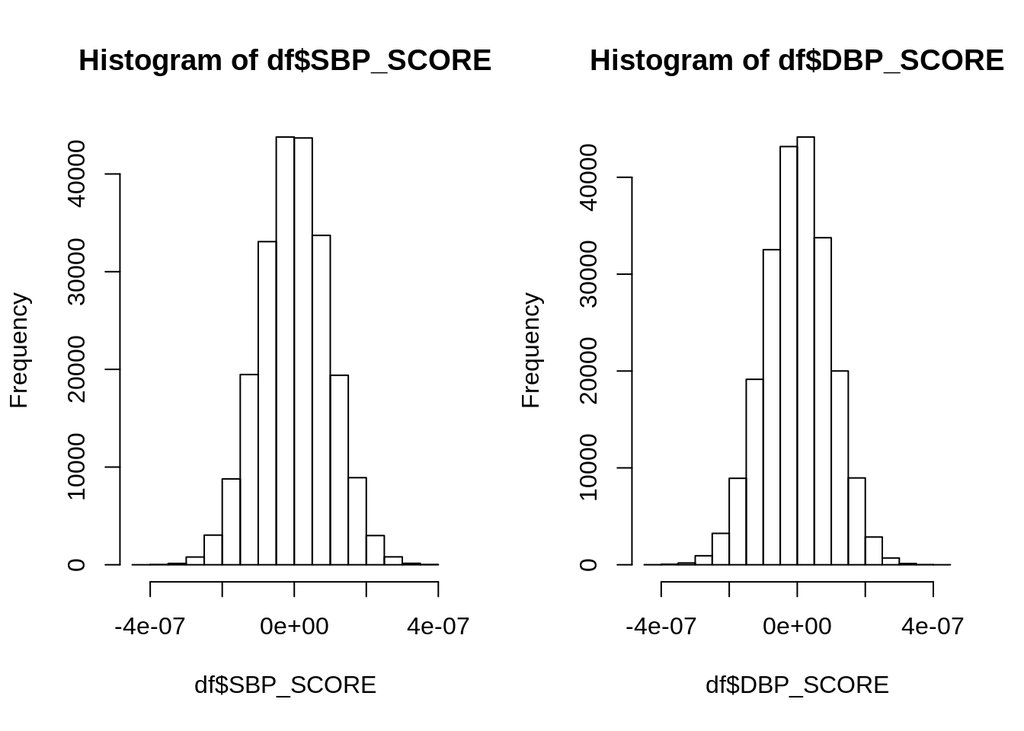

```r
par(mfrow=c(1,2))
hist(df$SBP_SCORE)
hist(df$DBP_SCORE)
```

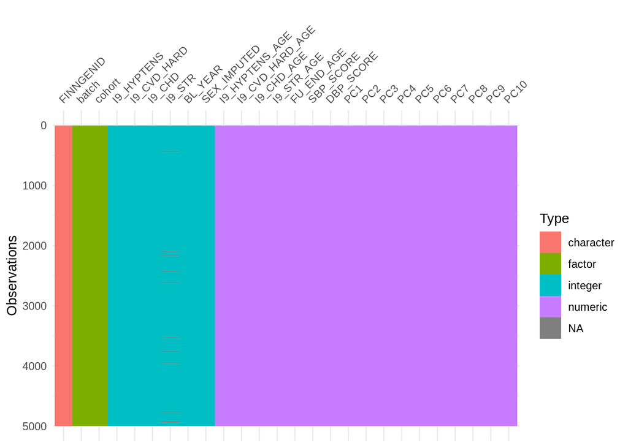

```r
par(mfrow=c(1,1))

#5000 random observations
df %>%
  sample_n(5000) %>%
  vis_dat()
```

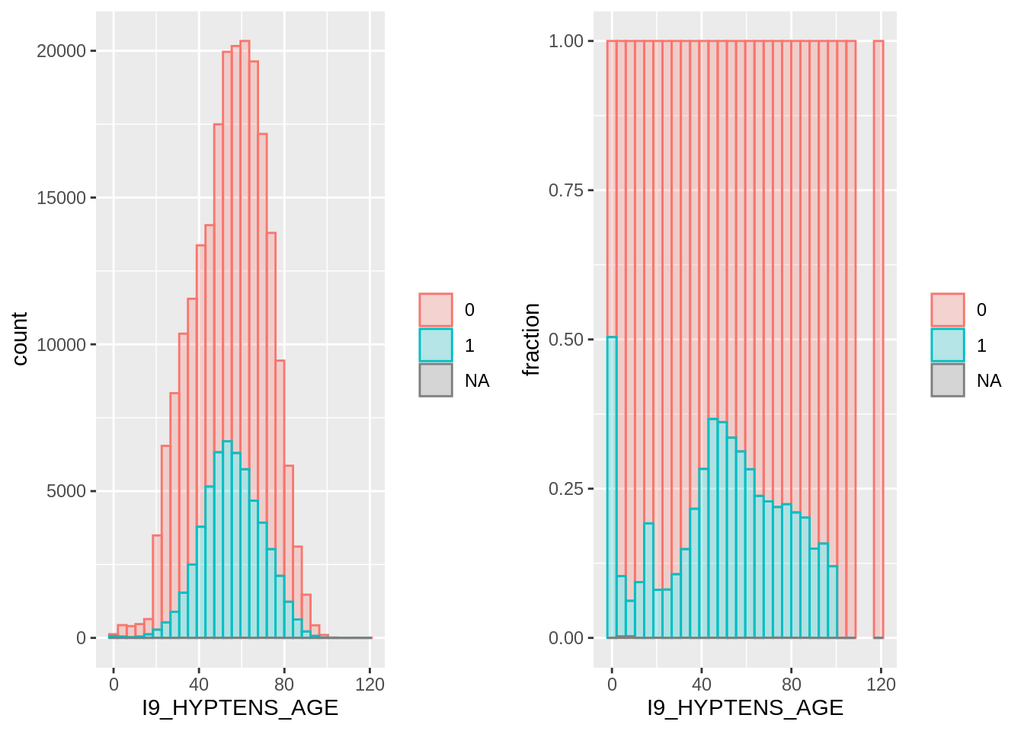

```r
p1 <-
  ggplot(df,aes(x=I9_HYPTENS_AGE, color=as.factor(I9_HYPTENS), fill=as.factor(I9_HYPTENS))) +
    geom_histogram(alpha=0.25) +
    theme(legend.title = element_blank())


p2 <-
  ggplot(df,aes(x=I9_HYPTENS_AGE, color=as.factor(I9_HYPTENS), fill=as.factor(I9_HYPTENS))) +
    geom_histogram(alpha=0.25, position="fill") +
    ylab("fraction") +
    theme(legend.title = element_blank())


grid.arrange(p1,p2, nrow=1)
```

**Creating scaled variables**

```r
df <- df %>%
  mutate(SBP_SCALED = scale(SBP_SCORE),
         DBP_SCALED = scale(DBP_SCORE))
```

**Dividing to late and early hypertension**

```r
df <- df %>%
  mutate(HT_EARLY = if_else(I9_HYPTENS_AGE >= 55, as.integer(0), I9_HYPTENS),
         HT_LATE  = if_else(I9_HYPTENS_AGE <  55,  as.integer(0), I9_HYPTENS),
         AGE_CAT  = if_else(I9_HYPTENS_AGE <  55, 1,2))
```

**Creating categorical variables**

Data was categorized also in Mars *et al.*, Nat.Med. 26, 549-557, (2020).

```r
#Let's add parametric versions of the scores
my_probs = c(0,0.025,0.2,0.8,0.975,1)
my_labels =  c("<2.5%","2.5-20%","20-80%","80-97.5%",">97.5%")

df <- df %>%
  mutate(
    SBP_CAT = cut(SBP_SCORE, breaks=quantile(df$SBP_SCORE, probs = my_probs), labels=my_labels, include.lowest = T),
    DBP_CAT = cut(DBP_SCORE, breaks=quantile(df$DBP_SCORE, probs = my_probs), labels=my_labels, include.lowest = T)
  )

#Let's create new dataframe for tables with 20-80% as reference.

df_r <- df %>%
  mutate(
    SBP_CAT = relevel(SBP_CAT, ref = "20-80%"),
    DBP_CAT = relevel(DBP_CAT, ref = "20-80%")
  )
```

Combined and processed data is written out

```r
saveRDS(df, file = "ht_prs.rds")
```

# 2 BP PRSs and hypertension

## 2.1 Proportional hazard assumption: log log curve

**Model by survfit**

```r
#SBP
km.sbp <- survfit(Surv(I9_HYPTENS_AGE, I9_HYPTENS) ~ SBP_CAT, data=df)
#print(km.sbp)

#DBP
km.dbp <- survfit(Surv(I9_HYPTENS_AGE, I9_HYPTENS) ~ DBP_CAT, data=df)
#print(km.dbp)
```

**log log curve**

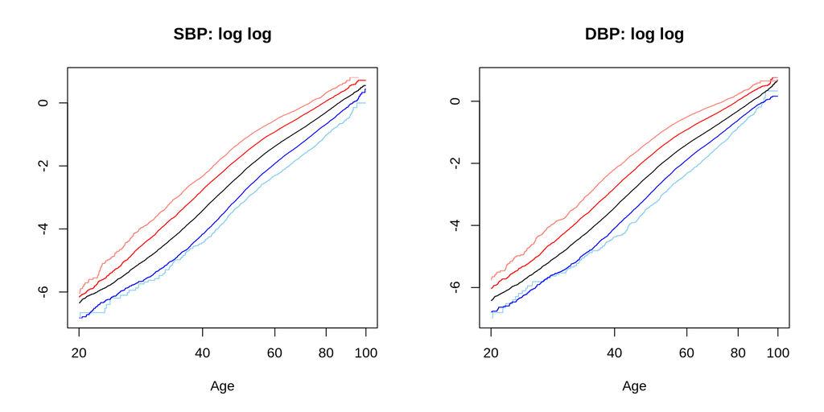

```r
cols= c("skyblue", "blue", "black", "red", "salmon")
labels= c("<2.5%","2.5-20%","20-80%","80-97.5%",">97.5%")

par(mfrow=c(1,2))

plot(km.sbp, fun="cloglog", xlim=c(20,100), main="SBP: log log", xlab="Age", col = cols)
plot(km.dbp, fun="cloglog", xlim=c(20,100), main="DBP: log log", xlab="Age", col = cols)
```

```r
par(mfrow=c(1,1))
```

These look parallel enough. We can use cox model.

## 2.2 Cox model: covariate adjusted, continuous score

**Running models**

```r
#Fitting cox for SBP_SCORE
cx.sbp.cs <- coxph(Surv(I9_HYPTENS_AGE, I9_HYPTENS) ~ SBP_SCALED + SEX_IMPUTED + batch + BL_YEAR + PC1 + PC2 + PC3 + PC4 + PC5 + PC6 + PC7 + PC8 + PC9 + PC10, data=df)

#Fitting cox for DBP_SCORE
cx.dbp.cs <- coxph(Surv(I9_HYPTENS_AGE, I9_HYPTENS) ~ DBP_SCALED + SEX_IMPUTED + batch + BL_YEAR + PC1 + PC2 + PC3 + PC4 + PC5 + PC6 + PC7 + PC8 + PC9 + PC10, data=df)
```

**Table: Hazard rations:**

```r
my_hr_table_cont2(list(cx.sbp.cs, cx.dbp.cs), c("SBP", "DBP")) %>%
  knitr::kable()
```

| name | HR (95% CI) | P-value |
| --- | --- | --- |
| SBP | 1.42 (1.41-1.43) | <1e-300 |
| DBP | 1.41 (1.4-1.42) | <1e-300 |

**All coefficients**

```r
summary(cx.sbp.cs)
```

```
## Call:
## coxph(formula = Surv(I9_HYPTENS_AGE, I9_HYPTENS) ~ SBP_SCALED +
##     SEX_IMPUTED + batch + BL_YEAR + PC1 + PC2 + PC3 + PC4 + PC5 +
##     PC6 + PC7 + PC8 + PC9 + PC10, data = df)
##
##   n= 218754, number of events= 55917
##    (38 observations deleted due to missingness)
##
##                                                        coef  exp(coef)
## SBP_SCALED                                        0.3499252  1.4189614
## SEX_IMPUTED                                      -0.1435232  0.8663007
## batchAxiomGT1_b02_V2P2.calls                     -0.1485577  0.8619503
## batchAxiomGT1_b03_V2P2.calls                     -0.0220022  0.9782381
## batchAxiomGT1_b04_V2P2.calls                      0.1453469  1.1564406
## batchAxiomGT1_b05_V2P2.calls                     -0.0613623  0.9404825
## batchAxiomGT1_b06_V2P2.calls                      0.0144845  1.0145899
## batchAxiomGT1_b07_V2P2.calls                      0.0215411  1.0217748
## batchAxiomGT1_b08_V2P2.calls                     -0.0515036  0.9498002
## batchAxiomGT1_b09_V2P2.calls                      0.0360015  1.0366574
## batchAxiomGT1_b10_V2P2.calls                      0.1531987  1.1655565
## batchAxiomGT1_b11_V2P2.calls                      0.1286674  1.1373118
## batchAxiomGT1_b12_V2P2.calls                      0.1012277  1.1065286
## batchAxiomGT1_b13_V2P2.calls                      0.3093285  1.3625098
## batchAxiomGT1_b14_V2P2.calls                      0.1092716  1.1154653
## batchAxiomGT1_b15_V2P2.calls                      0.3434659  1.4098255
## batchAxiomGT1_b16_V2P2.calls                     -0.1413497  0.8681857
## batchAxiomGT1_b17_V2P2.calls                      0.1358669  1.1455294
## batchAxiomGT1_b18_V2P2.calls                      0.4083987  1.5044069
## batchAxiomGT1_b19_V2P2.calls                     -0.2380453  0.7881670
## batchAxiomGT1_b20_V2P2.calls                      0.3214862  1.3791759
## batchAxiomGT1_b21_V2P2.calls                      0.1457775  1.1569387
## batchAxiomGT1_b22_V2P2.calls                      0.3512938  1.4209048
## batchAxiomGT1_b23_V2P2.calls                      0.1808333  1.1982154
## batchAxiomGT1_b24_V2P2.calls                     -0.2272836  0.7966948
## batchAxiomGT1_b25_V2P2.calls                      0.1953119  1.2156902
## batchAxiomGT1_b26_V2P2.calls                      0.2459027  1.2787751
## batchAxiomGT1_b27_V2P2.calls                     -0.3952388  0.6735192
## batchAxiomGT1_b28_V2P2.calls                      0.0848936  1.0886013
## batchAxiomGT1_b29_V2P2.calls                      0.2511746  1.2855346
## batchAxiomGT1_b30_V2P2.calls                      0.1955035  1.2159230
```

[output cut: 341 more lines]

```
## PC1                                               0.086356
## PC2                                              29.028744
## PC3                                               0.381759
## PC4                                               0.022393
## PC5                                              37.117300
## PC6                                              10.492198
## PC7                                               1.739117
## PC8                                               1.785813
## PC9                                               2.053389
## PC10                                              0.005593
##
## Concordance= 0.634  (se = 0.001 )
## Likelihood ratio test= 9726  on 75 df,   p=<2e-16
## Wald test            = 9700  on 75 df,   p=<2e-16
## Score (logrank) test = 9770  on 75 df,   p=<2e-16
```

```r
summary(cx.dbp.cs)
```

```
## Call:
## coxph(formula = Surv(I9_HYPTENS_AGE, I9_HYPTENS) ~ DBP_SCALED +
##     SEX_IMPUTED + batch + BL_YEAR + PC1 + PC2 + PC3 + PC4 + PC5 +
##     PC6 + PC7 + PC8 + PC9 + PC10, data = df)
##
##   n= 218754, number of events= 55917
##    (38 observations deleted due to missingness)
##
##                                                        coef  exp(coef)
## DBP_SCALED                                        0.3428909  1.4090150
## SEX_IMPUTED                                      -0.1443402  0.8655932
## batchAxiomGT1_b02_V2P2.calls                     -0.1490734  0.8615059
## batchAxiomGT1_b03_V2P2.calls                     -0.0272419  0.9731258
## batchAxiomGT1_b04_V2P2.calls                      0.1378550  1.1478091
## batchAxiomGT1_b05_V2P2.calls                     -0.0715852  0.9309169
## batchAxiomGT1_b06_V2P2.calls                      0.0038862  1.0038938
## batchAxiomGT1_b07_V2P2.calls                      0.0008450  1.0008454
## batchAxiomGT1_b08_V2P2.calls                     -0.0660218  0.9361105
## batchAxiomGT1_b09_V2P2.calls                      0.0317654  1.0322753
## batchAxiomGT1_b10_V2P2.calls                      0.1383260  1.1483498
## batchAxiomGT1_b11_V2P2.calls                      0.1171118  1.1242451
## batchAxiomGT1_b12_V2P2.calls                      0.0913883  1.0956944
## batchAxiomGT1_b13_V2P2.calls                      0.3050642  1.3567121
## batchAxiomGT1_b14_V2P2.calls                      0.0984596  1.1034698
## batchAxiomGT1_b15_V2P2.calls                      0.3370531  1.4008135
## batchAxiomGT1_b16_V2P2.calls                     -0.1585800  0.8533547
## batchAxiomGT1_b17_V2P2.calls                      0.1191339  1.1265208
## batchAxiomGT1_b18_V2P2.calls                      0.4166377  1.5168528
## batchAxiomGT1_b19_V2P2.calls                     -0.2672139  0.7655093
## batchAxiomGT1_b20_V2P2.calls                      0.3053437  1.3570913
## batchAxiomGT1_b21_V2P2.calls                      0.1378133  1.1477613
## batchAxiomGT1_b22_V2P2.calls                      0.3411837  1.4066116
## batchAxiomGT1_b23_V2P2.calls                      0.1697868  1.1850521
## batchAxiomGT1_b24_V2P2.calls                     -0.2409037  0.7859173
## batchAxiomGT1_b25_V2P2.calls                      0.1990395  1.2202301
## batchAxiomGT1_b26_V2P2.calls                      0.2345348  1.2643205
## batchAxiomGT1_b27_V2P2.calls                     -0.4037999  0.6677777
## batchAxiomGT1_b28_V2P2.calls                      0.0786517  1.0818275
## batchAxiomGT1_b29_V2P2.calls                      0.2418625  1.2736190
## batchAxiomGT1_b30_V2P2.calls                      0.1897431  1.2089390
```

[output cut: 341 more lines]

```
## PC1                                               0.212389
## PC2                                              28.447966
## PC3                                               0.842435
## PC4                                               0.124974
## PC5                                              10.531001
## PC6                                               0.007344
## PC7                                               1.091863
## PC8                                               3.906816
## PC9                                               2.685693
## PC10                                              0.002899
##
## Concordance= 0.633  (se = 0.001 )
## Likelihood ratio test= 9217  on 75 df,   p=<2e-16
## Wald test            = 9171  on 75 df,   p=<2e-16
## Score (logrank) test = 9239  on 75 df,   p=<2e-16
```

## 2.3 Cox model: adjusted, continuous, by age

```r
#Young
cx.sbp.cs.y <- coxph(Surv(I9_HYPTENS_AGE, HT_EARLY) ~ SBP_SCALED + SEX_IMPUTED + batch + BL_YEAR + PC1 + PC2 + PC3 + PC4 + PC5 + PC6 + PC7 + PC8 + PC9 + PC10, data=df)
cx.dbp.cs.y <- coxph(Surv(I9_HYPTENS_AGE, HT_EARLY) ~ DBP_SCALED + SEX_IMPUTED + batch + BL_YEAR + PC1 + PC2 + PC3 + PC4 + PC5 + PC6 + PC7 + PC8 + PC9 + PC10, data=df)

#Old
cx.sbp.cs.o <- coxph(Surv(I9_HYPTENS_AGE, HT_LATE) ~ SBP_SCALED + SEX_IMPUTED + batch + BL_YEAR + PC1 + PC2 + PC3 + PC4 + PC5 + PC6 + PC7 + PC8 + PC9 + PC10, data=df)
cx.dbp.cs.o <- coxph(Surv(I9_HYPTENS_AGE, HT_LATE) ~ DBP_SCALED + SEX_IMPUTED + batch + BL_YEAR + PC1 + PC2 + PC3 + PC4 + PC5 + PC6 + PC7 + PC8 + PC9 + PC10, data=df)
```

**Hazard ratios/early**

```r
my_hr_table_cont2(list(cx.sbp.cs.y, cx.dbp.cs.y), c("SBP", "DBP")) %>%
  knitr::kable()
```

| name | HR (95% CI) | P-value |
| --- | --- | --- |
| SBP | 1.54 (1.53-1.56) | <1e-300 |
| DBP | 1.58 (1.56-1.6) | <1e-300 |

**Hazard ratios/late**

```r
my_hr_table_cont2(list(cx.sbp.cs.o, cx.dbp.cs.o), c("SBP", "DBP")) %>%
  knitr::kable()
```

| name | HR (95% CI) | P-value |
| --- | --- | --- |
| SBP | 1.31 (1.29-1.32) | <1e-300 |
| DBP | 1.26 (1.25-1.28) | 2.2e-293 |